# Survival Analysis Practical

Mohd Azmi, Mohd Khairul Anwar, Mohd Nasrullah, Mohd Hazwan

15/11/2019

# 1 Preface

## 1.1 Research Problem

The dataset taken from Worcester Heart Attack Study. The dataset contain 500 samples, to study factors and time trends associated with long-term survival following acute myocardial infarction.

In this study, we would like to ascertain factors associated with survival following acute myocardial infarction, and predict survival probability.

## 1.2 Library

```r
library(pacman)
p_load(haven, dplyr, psych, lubridate, knitr, ggplot2, survival, broom, survminer, mfp)
```

## 1.3 Data Wrangling

Import dataset

```r
WHASDS <- read_spss("whas500.sav")
WHASDS
```

```
## # A tibble: 500 x 22
##       id   age gender    hr sysbp diasbp   bmi   cvd   afb   sho   chf   av3
##    <dbl> <dbl>  <dbl> <dbl> <dbl>  <dbl> <dbl> <dbl> <dbl> <dbl> <dbl> <dbl>
##  1     1    83      0    89   152     78  25.5     1     1     0     0     0
##  2     2    49      0    84   120     60  24.0     1     0     0     0     0
##  3     3    70      1    83   147     88  22.1     0     0     0     0     0
##  4     4    70      0    65   123     76  26.6     1     0     0     1     0
##  5     5    70      0    63   135     85  24.4     1     0     0     0     0
##  6     6    70      0    76    83     54  23.2     1     0     0     0     1
##  7     7    57      0    73   191    116  39.5     1     0     0     0     0
##  8     8    55      0    91   147     95  27.1     1     0     0     0     0
##  9     9    88      1    63   209    100  27.4     1     0     0     1     0
## 10    10    54      0   104   166    106  25.5     1     0     0     0     0
## # ... with 490 more rows, and 10 more variables: miord <dbl>, mitype <dbl>,
## #   year <dbl>, los <dbl>, dstat <dbl>, lenfol <dbl>, fstat <dbl>,
## #   admitdate <date>, disdate <date>, fdate <date>
```

Convert to categorical data

```r
WHASDS2 <- WHASDS %>%
  mutate(gender = factor(gender,
                         labels = c("male", "female")),
         MIOrder = factor(miord,
                          labels = c("first", "recurrent")),
         MIType = factor(mitype,
                         labels = c("non Q-wave", "Q-wave")),
         FUpStatus = factor(fstat,
                            labels = c("alive", "dead"))) %>%
  select (id,
          FUpStatus,
          admitdate,
          fdate,
          lenfol,
          age,
          gender,
          bmi,
          sysbp,
          MIOrder,
          MIType)
WHASDS2
```

```
## # A tibble: 500 x 11
##       id FUpStatus admitdate  fdate      lenfol   age gender   bmi sysbp MIOrder
##    <dbl> <fct>     <date>     <date>      <dbl> <dbl> <fct>  <dbl> <dbl> <fct>
##  1     1 alive     1997-01-13 2002-12-31   2178    83 male    25.5   152 recurr~
##  2     2 alive     1997-01-19 2002-12-31   2172    49 male    24.0   120 first
##  3     3 alive     1997-01-01 2002-12-31   2190    70 female  22.1   147 first
##  4     4 dead      1997-02-17 1997-12-11    297    70 male    26.6   123 first
##  5     5 alive     1997-03-01 2002-12-31   2131    70 male    24.4   135 first
##  6     6 dead      1997-03-11 1997-03-12      1    70 male    23.2    83 first
##  7     7 alive     1997-03-10 2002-12-31   2122    57 male    39.5   191 first
##  8     8 dead      1997-01-11 2001-02-15   1496    55 male    27.1   147 first
##  9     9 dead      1996-12-31 1999-07-09    920    88 female  27.4   209 first
## 10    10 alive     1997-01-16 2002-12-31   2175    54 male    25.5   166 first
## # ... with 490 more rows, and 1 more variable: MIType <fct>
```

calculate duration

```r
WHASDS2 <- WHASDS2 %>%
  mutate(dur = as.duration(WHASDS2$admitdate %--% WHASDS2$fdate),
         dur_day = dur/ddays(1),
         dur_year = dur/dyears(1)) %>%
  select (id,
          FUpStatus,
          dur_year,
          age,
          gender,
          bmi,
          sysbp,
          MIOrder,
          MIType,
          admitdate,
          fdate,
          dur_day,
          lenfol)
WHASDS2
```

```
## # A tibble: 500 x 13
##       id FUpStatus dur_year   age gender   bmi sysbp MIOrder MIType admitdate
##    <dbl> <fct>        <dbl> <dbl> <fct>  <dbl> <dbl> <fct>   <fct>  <date>
##  1     1 alive      5.97       83 male    25.5   152 recurr~ non Q~ 1997-01-13
##  2     2 alive      5.95       49 male    24.0   120 first   Q-wave 1997-01-19
##  3     3 alive      6          70 female  22.1   147 first   Q-wave 1997-01-01
##  4     4 dead       0.814      70 male    26.6   123 first   Q-wave 1997-02-17
##  5     5 alive      5.84       70 male    24.4   135 first   Q-wave 1997-03-01
##  6     6 dead       0.00274    70 male    23.2    83 first   non Q~ 1997-03-11
##  7     7 alive      5.81       57 male    39.5   191 first   Q-wave 1997-03-10
##  8     8 dead       4.10       55 male    27.1   147 first   Q-wave 1997-01-11
##  9     9 dead       2.52       88 female  27.4   209 first   non Q~ 1996-12-31
## 10    10 alive      5.96       54 male    25.5   166 first   non Q~ 1997-01-16
## # ... with 490 more rows, and 3 more variables: fdate <date>, dur_day <dbl>,
## #   lenfol <dbl>
```

# 2 Descriptive Study

## 2.1 Summary

Most of the participant was gender (n=300), first MI episode (n=329) and non Q-wave type (n=347). The mean age of the participant was 69.85 years old, with mean BMI 26.61 m/kg<sup>2</sup>, and mean systolic BP of 145 mmHg.

```r
WHASDS2 %>%
  select_if(is.numeric) %>%
  summary() %>%
  kable()
```

|  | id | dur_year | age | bmi | sysbp | dur_day | lenfol |
| --- | --- | --- | --- | --- | --- | --- | --- |
|  | Min. : 1.0 | Min. :0.00274 | Min. : 30.00 | Min. :13.05 | Min. : 57.0 | Min. : 1.0 | Min. : 1.0 |
|  | 1st Qu.:125.8 | 1st Qu.:0.81233 | 1st Qu.: 59.00 | 1st Qu.:23.22 | 1st Qu.:123.0 | 1st Qu.: 296.5 | 1st Qu.: 296.5 |
|  | Median :250.5 | Median :1.73014 | Median : 72.00 | Median :25.95 | Median :141.5 | Median : 631.5 | Median : 631.5 |
|  | Mean :250.5 | Mean :2.41763 | Mean : 69.85 | Mean :26.61 | Mean :144.7 | Mean : 882.4 | Mean : 882.4 |
|  | 3rd Qu.:375.2 | 3rd Qu.:3.73562 | 3rd Qu.: 82.00 | 3rd Qu.:29.39 | 3rd Qu.:164.0 | 3rd Qu.:1363.5 | 3rd Qu.:1363.5 |
|  | Max. :500.0 | Max. :6.46027 | Max. :104.00 | Max. :44.84 | Max. :244.0 | Max. :2358.0 | Max. :2358.0 |

```r
WHASDS2 %>%
  select_if(is.factor) %>%
  summary() %>%
  kable()
```

|  | FUpStatus | gender | MIOrder | MIType |
| --- | --- | --- | --- | --- |
|  | alive:285 | male :300 | first :329 | non Q-wave:347 |
|  | dead :215 | female:200 | recurrent:171 | Q-wave :153 |

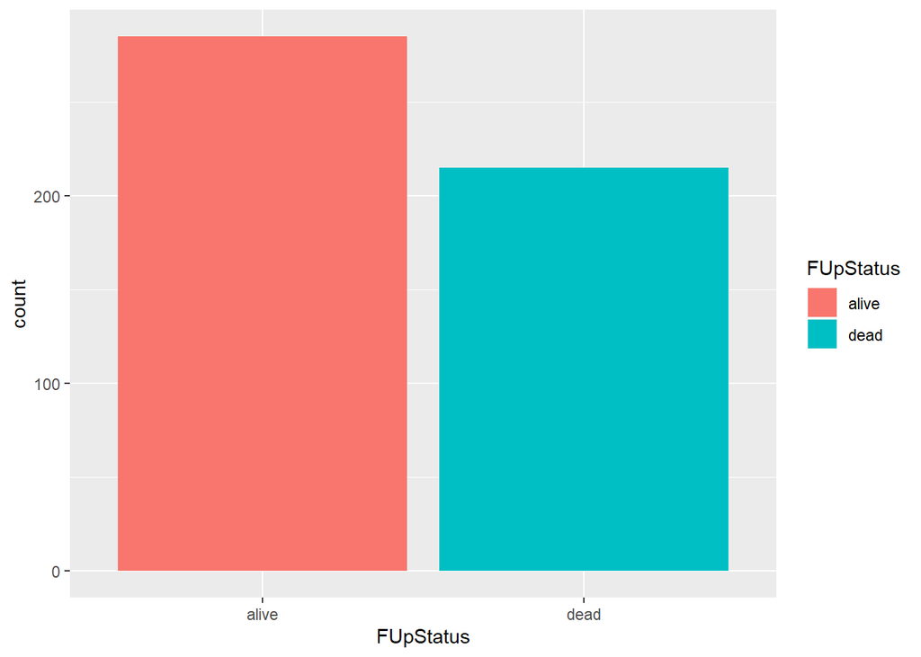

```r
ggplot(WHASDS2, aes(x=FUpStatus, fill=FUpStatus)) +
  geom_bar()
```

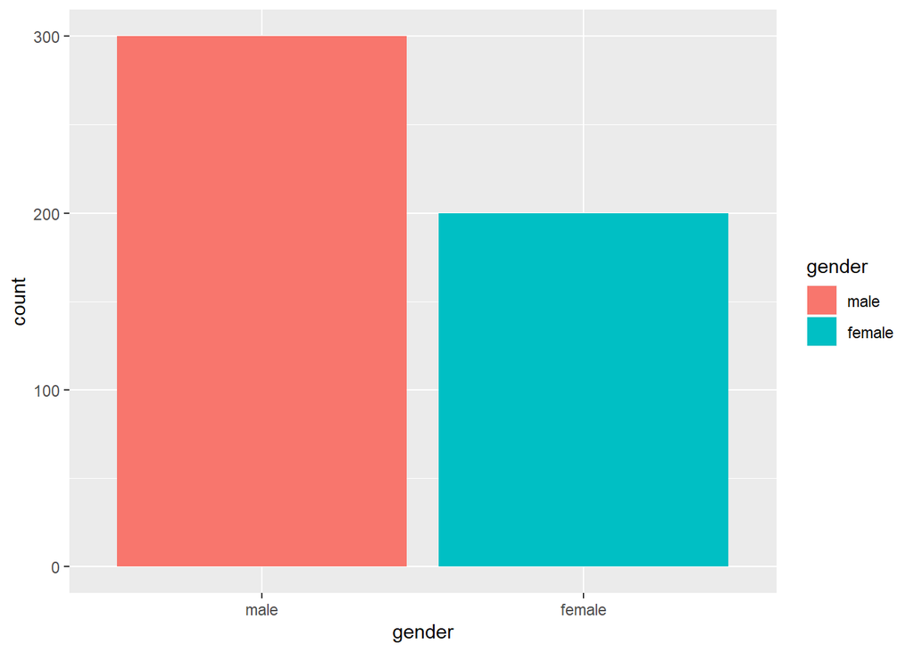

```r
ggplot(WHASDS2, aes(x=gender, fill=gender)) +
  geom_bar()
```

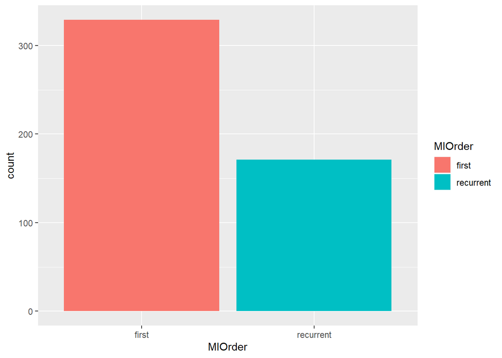

```r
ggplot(WHASDS2, aes(x=MIOrder, fill=MIOrder)) +
  geom_bar()
```

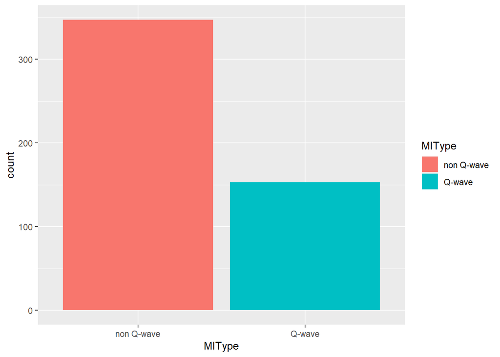

```r
ggplot(WHASDS2, aes(x=MIType, fill=MIType)) +
  geom_bar()
```

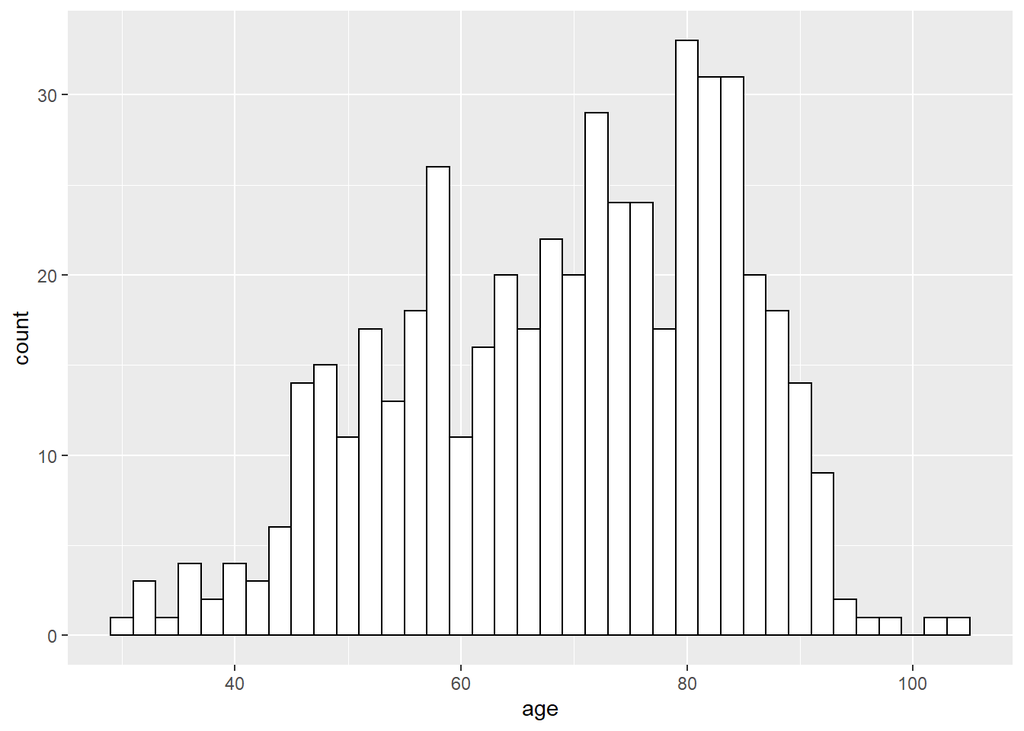

```r
ggplot(WHASDS2, aes(age)) +
  geom_histogram(binwidth=2, colour="black", fill="white")
```

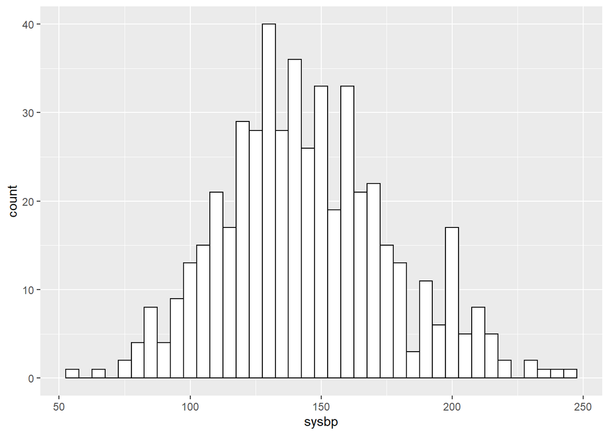

```r
ggplot(WHASDS2, aes(sysbp)) +
  geom_histogram(binwidth=5, colour="black", fill="white")
```

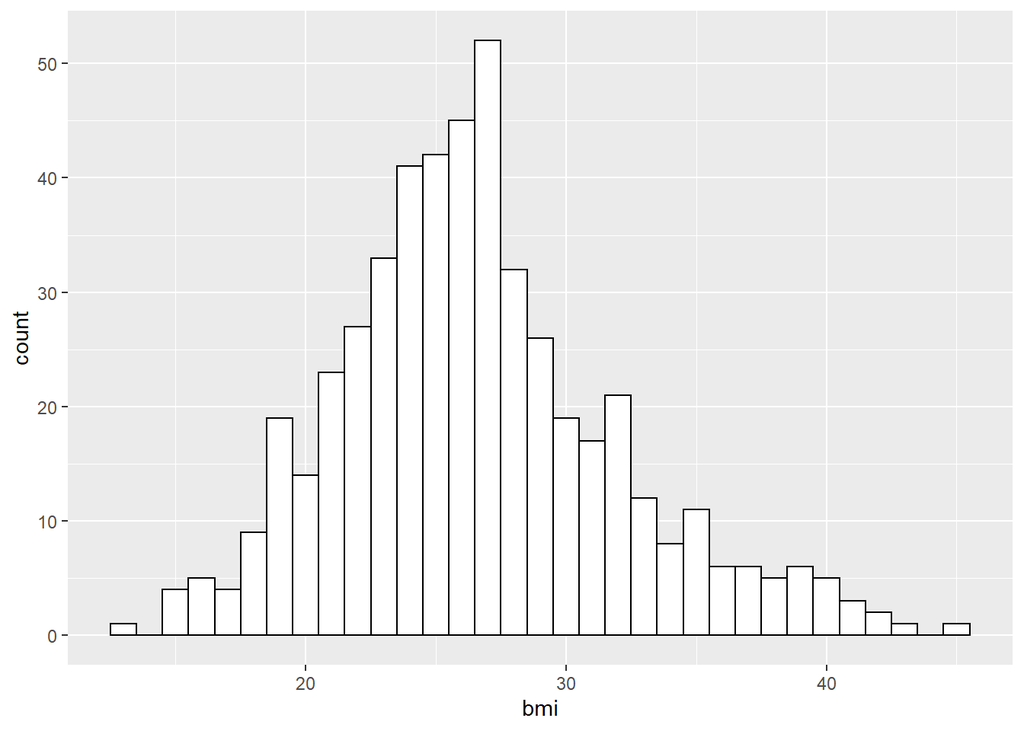

```r
ggplot(WHASDS2, aes(bmi)) +
  geom_histogram(binwidth=1, colour="black", fill="white")
```

Barchart for all categorical data, divide by follow up status

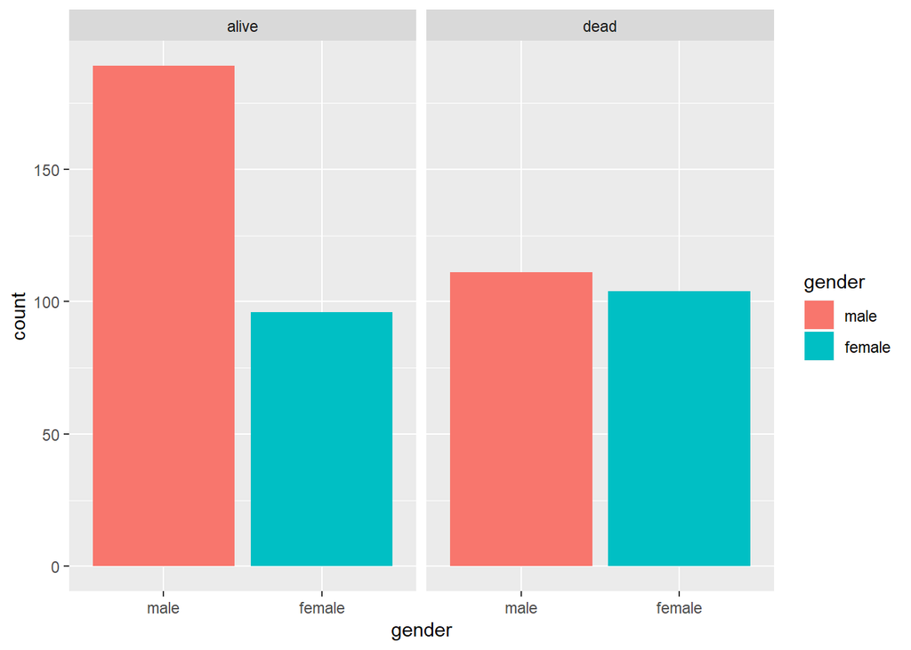

```r
ggplot(WHASDS2, aes(x=gender, fill=gender)) +
  geom_bar() +
  facet_wrap(~FUpStatus)
```

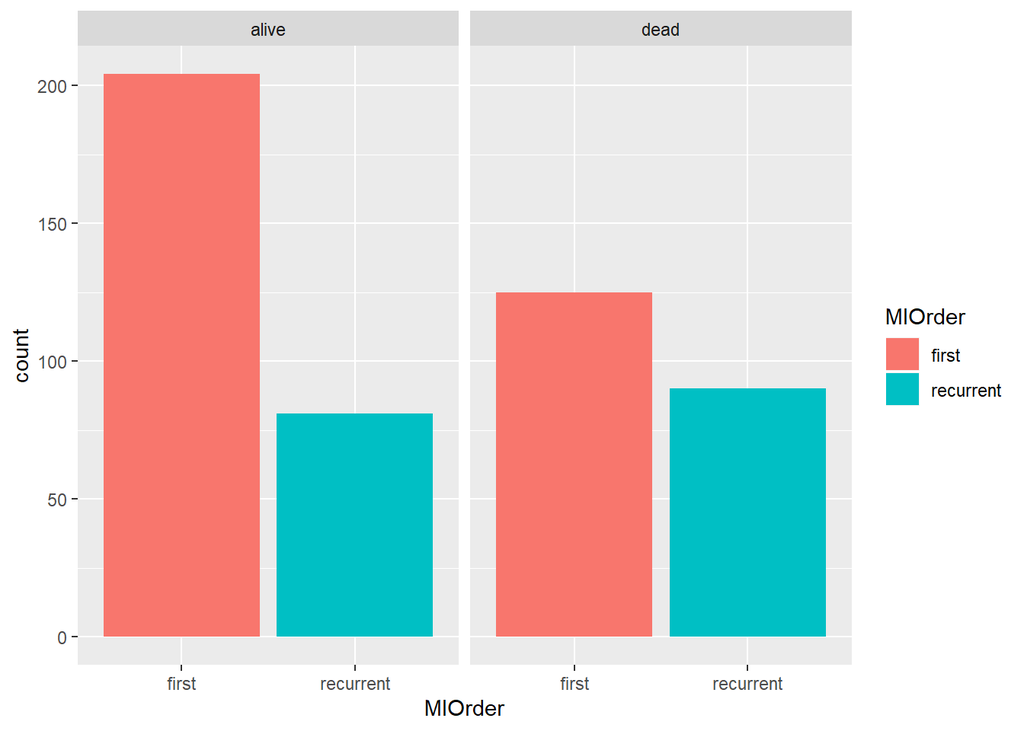

```r
ggplot(WHASDS2, aes(x=MIOrder, fill=MIOrder)) +
  geom_bar() +
  facet_wrap(~FUpStatus)
```

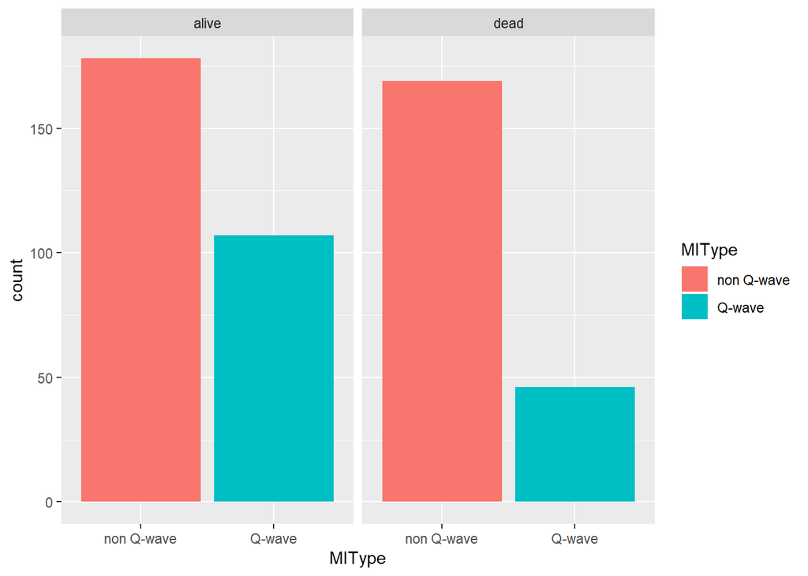

```r
ggplot(WHASDS2, aes(x=MIType, fill=MIType)) +
  geom_bar() +
  facet_wrap(~FUpStatus)
```

histogram for all numerical data, divide by follow up status **to add normal curve**

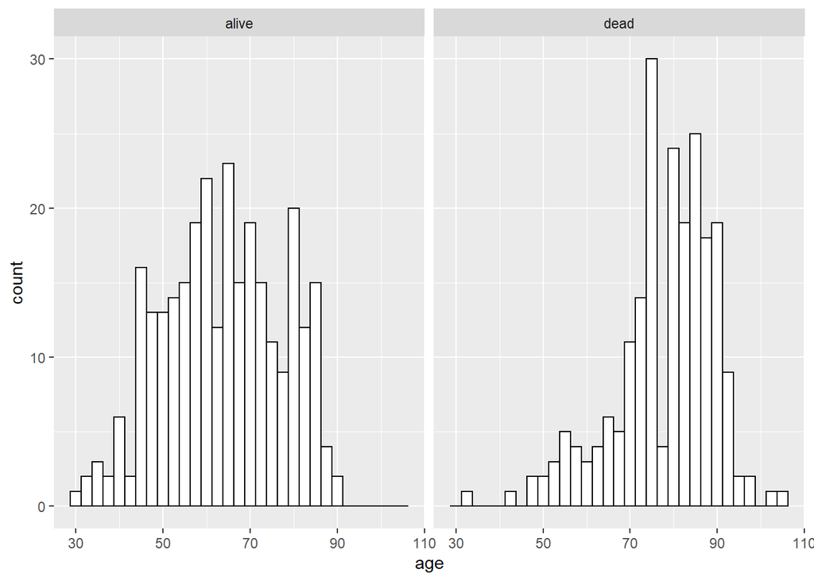

```r
ggplot(WHASDS2, aes(age)) +
  geom_histogram(binwidth=2.5, colour="black", fill="white") +
  facet_wrap(~FUpStatus)
```

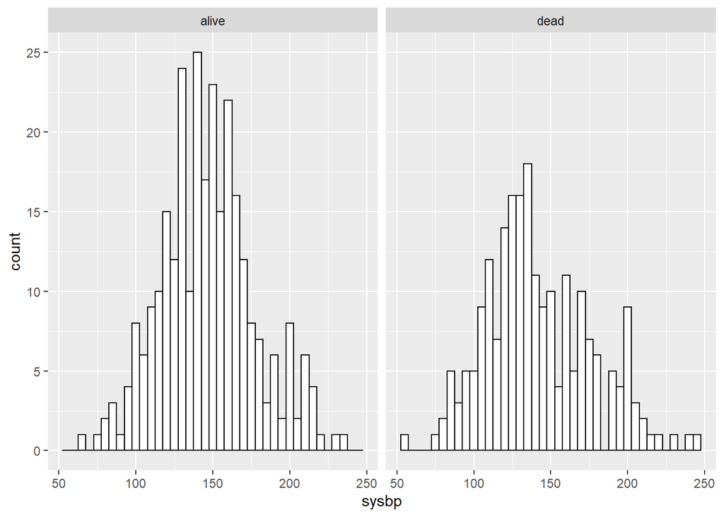

```r
ggplot(WHASDS2, aes(sysbp)) +
  geom_histogram(binwidth=5, colour="black", fill="white") +
  facet_wrap(~FUpStatus)
```

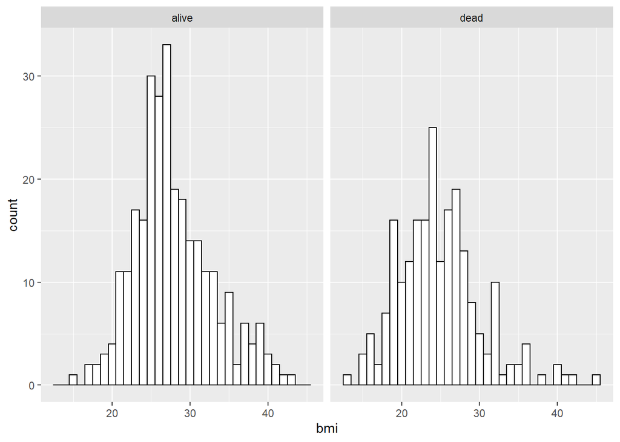

```r
ggplot(WHASDS2, aes(bmi)) +
  geom_histogram(binwidth=1, colour="black", fill="white") +
  facet_wrap(~FUpStatus)
```

## 2.2 KM Estimate For Overall Participants

The overall median survival time was 4.46 years (95% CI = 4.18, NA).

```r
Overall_KM <- survfit(Surv(time = dur_year, FUpStatus == "dead") ~1,
                      data = WHASDS2,
                      type = "kaplan-meier")
Overall_KM
```

```
## Call: survfit(formula = Surv(time = dur_year, FUpStatus == "dead") ~
##     1, data = WHASDS2, type = "kaplan-meier")
##
##       n  events  median 0.95LCL 0.95UCL
##  500.00  215.00    4.46    4.18      NA
```

## 2.3 KM Plot for Overall Participants

The KM plot for overall participant is shown below.

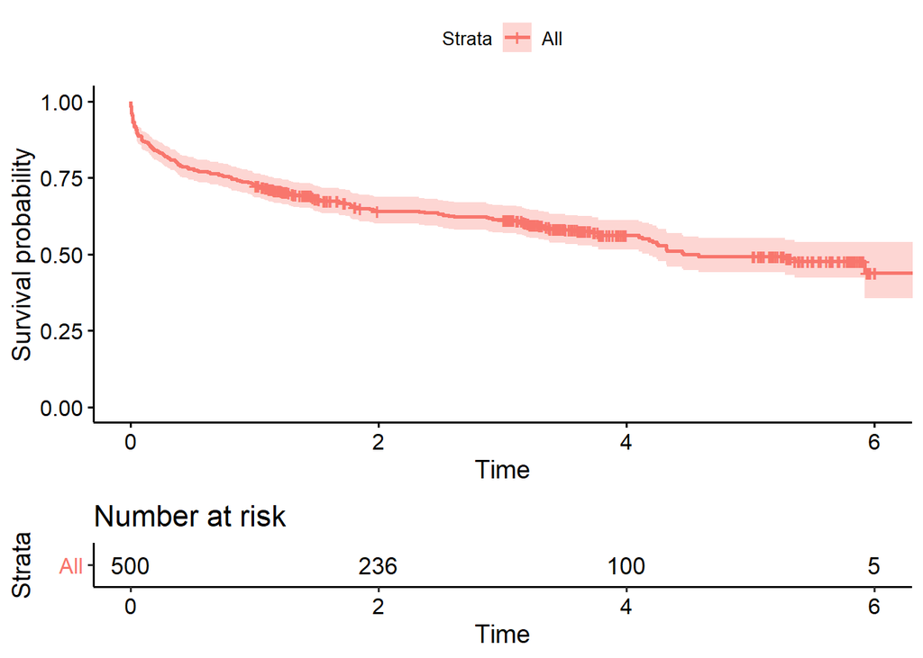

```r
ggsurvplot(Overall_KM,
           data = WHASDS2,
           risk.table = T)
```

## 2.4 Survival Probability

The 5-year survival probability was 49.4% (95% CI = 44.1%, 55.3%). Other survival probability (for 6 months, 1 year and 3 years) was shown below.

```r
summary(Overall_KM, times = c(0.5, 1, 3, 5))
```

```
## Call: survfit(formula = Surv(time = dur_year, FUpStatus == "dead") ~
##     1, data = WHASDS2, type = "kaplan-meier")
##
##  time n.risk n.event survival std.err lower 95% CI upper 95% CI
##   0.5    390     110    0.780  0.0185        0.745        0.817
##   1.0    362      28    0.724  0.0200        0.686        0.764
##   3.0    226      44    0.614  0.0229        0.571        0.661
##   5.0     88      27    0.494  0.0285        0.441        0.553
```

# 3 Univariable

## 3.1 Univariable - Age

### 3.1.1 Cox Proportional Hazard

For each 1 year increase of age, the log hazard to die changes by a factor of 0.07 (95% 0.05, 0.08, p < 0.001).

```r
age_CPH <- coxph(Surv(time = dur_year, FUpStatus == "dead") ~age,
                 data = WHASDS2)
tidy(age_CPH)
```

```
## # A tibble: 1 x 7
##   term  estimate std.error statistic  p.value conf.low conf.high
##   <chr>    <dbl>     <dbl>     <dbl>    <dbl>    <dbl>     <dbl>
## 1 age     0.0663   0.00608      10.9 1.01e-27   0.0544    0.0783
```

```r
tidy(exponentiate = T, age_CPH)
```

```
## # A tibble: 1 x 7
##   term  estimate std.error statistic  p.value conf.low conf.high
##   <chr>    <dbl>     <dbl>     <dbl>    <dbl>    <dbl>     <dbl>
## 1 age       1.07   0.00608      10.9 1.01e-27     1.06      1.08
```

## 3.2 Univariable - Gender

### 3.2.1 KM Estimate

```r
gender_KM <- survfit(Surv(time = dur_year, FUpStatus == "dead") ~gender,
                      data = WHASDS2,
                      type = "kaplan-meier")
gender_KM
```

```
## Call: survfit(formula = Surv(time = dur_year, FUpStatus == "dead") ~
##     gender, data = WHASDS2, type = "kaplan-meier")
##
##                 n events median 0.95LCL 0.95UCL
## gender=male   300    111   5.92    4.58      NA
## gender=female 200    104   3.61    2.48    4.46
```

### 3.2.2 KM Plot

KM Plot for gender was shown below

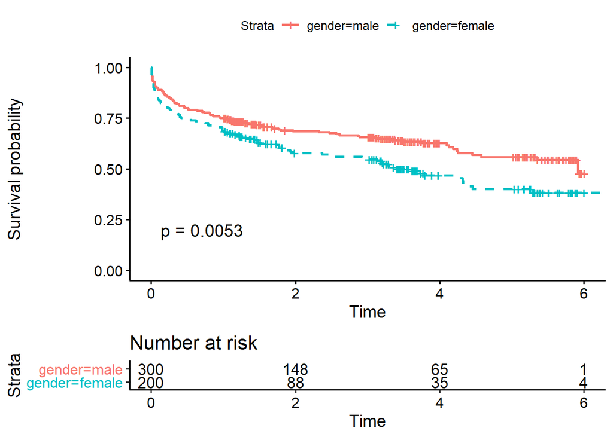

```r
ggsurvplot(gender_KM,
           data = WHASDS2,
           risk.table = T,
           linetype = c(1,2),
           pval = T)
```

### 3.2.3 Cox Proportional Hazard

```r
gender_CPH <- coxph(Surv(time = dur_year, FUpStatus == "dead") ~gender,
                 data = WHASDS2)
tidy(gender_CPH)
```

```
## # A tibble: 1 x 7
##   term         estimate std.error statistic p.value conf.low conf.high
##   <chr>           <dbl>     <dbl>     <dbl>   <dbl>    <dbl>     <dbl>
## 1 genderfemale    0.382     0.138      2.77 0.00556    0.112     0.651
```

```r
tidy(gender_CPH, exponentiate =  T)
```

```
## # A tibble: 1 x 7
##   term         estimate std.error statistic p.value conf.low conf.high
##   <chr>           <dbl>     <dbl>     <dbl>   <dbl>    <dbl>     <dbl>
## 1 genderfemale     1.46     0.138      2.77 0.00556     1.12      1.92
```

## 3.3 Univariable - BMI

### 3.3.1 Cox Proportional Hazard

For each 1 unit increase of BMI, the log hazard to die changes by a factor of -0.10 (95% = -0.13, -0.07, p < 0.001).

```r
BMI_CPH <- coxph(Surv(time = dur_year, FUpStatus == "dead") ~bmi,
                 data = WHASDS2)
tidy(BMI_CPH)
```

```
## # A tibble: 1 x 7
##   term  estimate std.error statistic  p.value conf.low conf.high
##   <chr>    <dbl>     <dbl>     <dbl>    <dbl>    <dbl>     <dbl>
## 1 bmi    -0.0985    0.0148     -6.68 2.46e-11   -0.127   -0.0696
```

```r
tidy(BMI_CPH, exponentiate = T)
```

```
## # A tibble: 1 x 7
##   term  estimate std.error statistic  p.value conf.low conf.high
##   <chr>    <dbl>     <dbl>     <dbl>    <dbl>    <dbl>     <dbl>
## 1 bmi      0.906    0.0148     -6.68 2.46e-11    0.880     0.933
```

## 3.4 Univariable - Systolic BP

### 3.4.1 Cox Proportional Hazard

For each 1 mmHg increase of Systolic BP, the log hazard to die changes by a factor of -0.005 (95% = - 0.008, - 0.0001, p = 0.042).

```r
SBP_CPH <- coxph(Surv(time = dur_year, FUpStatus == "dead") ~sysbp,
                 data = WHASDS2)
tidy(SBP_CPH)
```

```
## # A tibble: 1 x 7
##   term  estimate std.error statistic p.value conf.low conf.high
##   <chr>    <dbl>     <dbl>     <dbl>   <dbl>    <dbl>     <dbl>
## 1 sysbp -0.00452   0.00223     -2.03  0.0423 -0.00888 -0.000157
```

```r
tidy(SBP_CPH, exponentiate = T)
```

```
## # A tibble: 1 x 7
##   term  estimate std.error statistic p.value conf.low conf.high
##   <chr>    <dbl>     <dbl>     <dbl>   <dbl>    <dbl>     <dbl>
## 1 sysbp    0.995   0.00223     -2.03  0.0423    0.991     1.000
```

## 3.5 Univariable - Type of MI Order

### 3.5.1 KM Estimate

The median survival time for first MI episode was 5.92 years (95% CI = 5.28, NA) and for recurrent MI episode was 3.38 years (95% CI = 2.33, 4.33). The survival time was significant different (p = 0.002)

```r
MIOrder_KM <- survfit(Surv(time = dur_year, FUpStatus == "dead") ~MIOrder,
                      data = WHASDS2,
                      type = "kaplan-meier")
MIOrder_KM
```

```
## Call: survfit(formula = Surv(time = dur_year, FUpStatus == "dead") ~
##     MIOrder, data = WHASDS2, type = "kaplan-meier")
##
##                     n events median 0.95LCL 0.95UCL
## MIOrder=first     329    125   5.92    5.28      NA
## MIOrder=recurrent 171     90   3.38    2.33    4.33
```

### 3.5.2 KM Plot

KM Plot for type of MI order was shown below

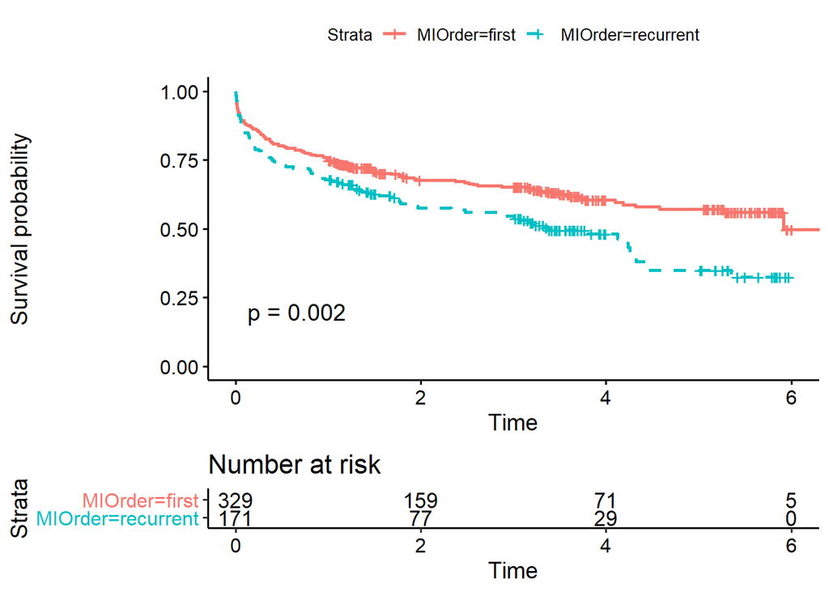

```r
ggsurvplot(MIOrder_KM,
           data = WHASDS2,
           risk.table = T,
           linetype = c(1,2),
           pval = T)
```

### 3.5.3 Cox Proportional Hazard

```r
MIOrder_CPH <- coxph(Surv(time = dur_year, FUpStatus == "dead") ~MIOrder,
                 data = WHASDS2)
tidy(MIOrder_CPH)
```

```
## # A tibble: 1 x 7
##   term             estimate std.error statistic p.value conf.low conf.high
##   <chr>               <dbl>     <dbl>     <dbl>   <dbl>    <dbl>     <dbl>
## 1 MIOrderrecurrent    0.427     0.139      3.07 0.00216    0.154     0.699
```

```r
tidy(MIOrder_CPH, exponentiate = T)
```

```
## # A tibble: 1 x 7
##   term             estimate std.error statistic p.value conf.low conf.high
##   <chr>               <dbl>     <dbl>     <dbl>   <dbl>    <dbl>     <dbl>
## 1 MIOrderrecurrent     1.53     0.139      3.07 0.00216     1.17      2.01
```

## 3.6 Univariable - Type of MI

### 3.6.1 KM Estimate

```r
MIType_KM <- survfit(Surv(time = dur_year, FUpStatus == "dead") ~MIType,
                      data = WHASDS2,
                      type = "kaplan-meier")
MIType_KM
```

```
## Call: survfit(formula = Surv(time = dur_year, FUpStatus == "dead") ~
##     MIType, data = WHASDS2, type = "kaplan-meier")
##
##                     n events median 0.95LCL 0.95UCL
## MIType=non Q-wave 347    169   3.50    2.89    4.46
## MIType=Q-wave     153     46   6.44    6.44      NA
```

### 3.6.2 KM Plot

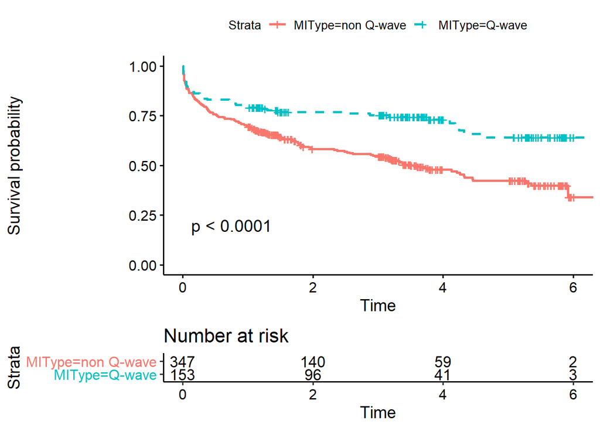

```r
ggsurvplot(MIType_KM,
           data = WHASDS2,
           risk.table = T,
           linetype = c(1,2),
           pval = T)
```

### 3.6.3 Cox Proportional Hazard

If the MI was Q-wave type, the hazard to die changes by a factor of 0.52 (95% CI = 0.37, 0.72, p < 0.001) compared to non Q-wave type.

```r
MIType_CPH <- coxph(Surv(time = dur_year, FUpStatus == "dead") ~MIType,
                 data = WHASDS2)
tidy(MIType_CPH)
```

```
## # A tibble: 1 x 7
##   term         estimate std.error statistic   p.value conf.low conf.high
##   <chr>           <dbl>     <dbl>     <dbl>     <dbl>    <dbl>     <dbl>
## 1 MITypeQ-wave   -0.660     0.167     -3.95 0.0000789   -0.988    -0.332
```

```r
tidy(MIType_CPH, exponentiate = T)
```

```
## # A tibble: 1 x 7
##   term         estimate std.error statistic   p.value conf.low conf.high
##   <chr>           <dbl>     <dbl>     <dbl>     <dbl>    <dbl>     <dbl>
## 1 MITypeQ-wave    0.517     0.167     -3.95 0.0000789    0.372     0.717
```

## 3.7 Univariable Summary

All variable was significant (at p < 0.05) in simple cox proportional hazard. The univariable analysis result was shown below.

```r
SCPH_Result <- matrix(c("Age", 0.07, "(0.05, 0.08)", "< 0.001",
                        "Gender (Female)", 0.38, " (0.11, 0.65)", 0.006,
                        "Systolic BP", -0.01, "(-0.01, 0.00)", 0.042,
                        "BMI (Numerical)", -0.10, "(-0.13, -0.07)", "<0.001",
                       "Type of MI Order (Recurrent)", 0.43, "(0.15, 0.70)", 0.002,
                        "Type of MI (Q-wave)", -0.66, "(-0.99, -0.33)", "<0.001"),
                      ncol = 4,
                      byrow = T)
colnames(SCPH_Result) <- c("Variables", "beta", "(95% CI)", "p-value")
kable(SCPH_Result)
```

| Variables | beta | (95% CI) | p-value |
| --- | --- | --- | --- |
| Age | 0.07 | (0.05, 0.08) | < 0.001 |
| Gender (Female) | 0.38 | (0.11, 0.65) | 0.006 |
| Systolic BP | -0.01 | (-0.01, 0.00) | 0.042 |
| BMI (Numerical) | -0.1 | (-0.13, -0.07) | <0.001 |
| Type of MI Order (Recurrent) | 0.43 | (0.15, 0.70) | 0.002 |
| Type of MI (Q-wave) | -0.66 | (-0.99, -0.33) | <0.001 |

# 4 Multivariable Analysis

For multivariable analysis (multiple cox proportional hazard model), all variable with significant simple cox proportional hazard (at p < 0.05) were included in main effect models. The variables are age, gender, systolic BP, BMI, MI order and type of MI.

## 4.1 Model 1

For Main Effect Model 1, variables included were age, gender, sbp, bmi, MI order and type of MI. The Cox Proportional Hazard model for Main Effect Model 1 was shown below.

### 4.1.1 Cox Propotional Hazard

```r
all_CPH <- coxph(Surv(time = dur_year,
                      FUpStatus == "dead") ~ age + gender + sysbp + bmi + MIOrder + MIType,
                 data = WHASDS2)
all_CPH
```

```
## Call:
## coxph(formula = Surv(time = dur_year, FUpStatus == "dead") ~
##     age + gender + sysbp + bmi + MIOrder + MIType, data = WHASDS2)
##
##                       coef exp(coef)  se(coef)      z       p
## age               0.058371  1.060108  0.006611  8.830 < 2e-16
## genderfemale     -0.080226  0.922907  0.141802 -0.566 0.57155
## sysbp            -0.004251  0.995758  0.002189 -1.942 0.05209
## bmi              -0.040141  0.960654  0.015490 -2.591 0.00956
## MIOrderrecurrent  0.104814  1.110504  0.145404  0.721 0.47100
## MITypeQ-wave     -0.274170  0.760203  0.178158 -1.539 0.12383
##
## Likelihood ratio test=157.4  on 6 df, p=< 2.2e-16
## n= 500, number of events= 215
```

```r
summary(all_CPH)
```

```
## Call:
## coxph(formula = Surv(time = dur_year, FUpStatus == "dead") ~
##     age + gender + sysbp + bmi + MIOrder + MIType, data = WHASDS2)
##
##   n= 500, number of events= 215
##
##                       coef exp(coef)  se(coef)      z Pr(>|z|)
## age               0.058371  1.060108  0.006611  8.830  < 2e-16 ***
## genderfemale     -0.080226  0.922907  0.141802 -0.566  0.57155
## sysbp            -0.004251  0.995758  0.002189 -1.942  0.05209 .
## bmi              -0.040141  0.960654  0.015490 -2.591  0.00956 **
## MIOrderrecurrent  0.104814  1.110504  0.145404  0.721  0.47100
## MITypeQ-wave     -0.274170  0.760203  0.178158 -1.539  0.12383
## ---
## Signif. codes:  0 '***' 0.001 '**' 0.01 '*' 0.05 '.' 0.1 ' ' 1
##
##                  exp(coef) exp(-coef) lower .95 upper .95
## age                 1.0601     0.9433    1.0465    1.0739
## genderfemale        0.9229     1.0835    0.6990    1.2186
## sysbp               0.9958     1.0043    0.9915    1.0000
## bmi                 0.9607     1.0410    0.9319    0.9903
## MIOrderrecurrent    1.1105     0.9005    0.8351    1.4767
## MITypeQ-wave        0.7602     1.3154    0.5361    1.0779
##
## Concordance= 0.743  (se = 0.017 )
## Likelihood ratio test= 157.4  on 6 df,   p=<2e-16
## Wald test            = 135.7  on 6 df,   p=<2e-16
## Score (logrank) test = 142.9  on 6 df,   p=<2e-16
```

```r
tidy(all_CPH)
```

```
## # A tibble: 6 x 7
##   term             estimate std.error statistic  p.value conf.low  conf.high
##   <chr>               <dbl>     <dbl>     <dbl>    <dbl>    <dbl>      <dbl>
## 1 age               0.0584    0.00661     8.83  1.05e-18  0.0454   0.0713
## 2 genderfemale     -0.0802    0.142      -0.566 5.72e- 1 -0.358    0.198
## 3 sysbp            -0.00425   0.00219    -1.94  5.21e- 2 -0.00854  0.0000385
## 4 bmi              -0.0401    0.0155     -2.59  9.56e- 3 -0.0705  -0.00978
## 5 MIOrderrecurrent  0.105     0.145       0.721 4.71e- 1 -0.180    0.390
## 6 MITypeQ-wave     -0.274     0.178      -1.54  1.24e- 1 -0.623    0.0750
```

## 4.2 Model 2

For Main Effect Model 2, variable gender were excluded from model 1. The Cox Proportional Hazard Model for Main Effect Model 2 was shown below.

```r
AllnoGender_CPH <- coxph(Surv(time = dur_year,
                      FUpStatus == "dead") ~ age + bmi + sysbp + MIOrder + MIType,
                 data = WHASDS2)
AllnoGender_CPH
```

```
## Call:
## coxph(formula = Surv(time = dur_year, FUpStatus == "dead") ~
##     age + bmi + sysbp + MIOrder + MIType, data = WHASDS2)
##
##                       coef exp(coef)  se(coef)      z      p
## age               0.057769  1.059471  0.006539  8.835 <2e-16
## bmi              -0.039508  0.961263  0.015382 -2.568 0.0102
## sysbp            -0.004354  0.995655  0.002183 -1.995 0.0461
## MIOrderrecurrent  0.110423  1.116751  0.145027  0.761 0.4464
## MITypeQ-wave     -0.268814  0.764285  0.177911 -1.511 0.1308
##
## Likelihood ratio test=157.1  on 5 df, p=< 2.2e-16
## n= 500, number of events= 215
```

```r
summary(AllnoGender_CPH)
```

```
## Call:
## coxph(formula = Surv(time = dur_year, FUpStatus == "dead") ~
##     age + bmi + sysbp + MIOrder + MIType, data = WHASDS2)
##
##   n= 500, number of events= 215
##
##                       coef exp(coef)  se(coef)      z Pr(>|z|)
## age               0.057769  1.059471  0.006539  8.835   <2e-16 ***
## bmi              -0.039508  0.961263  0.015382 -2.568   0.0102 *
## sysbp            -0.004354  0.995655  0.002183 -1.995   0.0461 *
## MIOrderrecurrent  0.110423  1.116751  0.145027  0.761   0.4464
## MITypeQ-wave     -0.268814  0.764285  0.177911 -1.511   0.1308
## ---
## Signif. codes:  0 '***' 0.001 '**' 0.01 '*' 0.05 '.' 0.1 ' ' 1
##
##                  exp(coef) exp(-coef) lower .95 upper .95
## age                 1.0595     0.9439    1.0460    1.0731
## bmi                 0.9613     1.0403    0.9327    0.9907
## sysbp               0.9957     1.0044    0.9914    0.9999
## MIOrderrecurrent    1.1168     0.8955    0.8404    1.4839
## MITypeQ-wave        0.7643     1.3084    0.5393    1.0832
##
## Concordance= 0.743  (se = 0.017 )
## Likelihood ratio test= 157.1  on 5 df,   p=<2e-16
## Wald test            = 134.6  on 5 df,   p=<2e-16
## Score (logrank) test = 142.5  on 5 df,   p=<2e-16
```

```r
tidy(AllnoGender_CPH)
```

```
## # A tibble: 5 x 7
##   term             estimate std.error statistic  p.value conf.low  conf.high
##   <chr>               <dbl>     <dbl>     <dbl>    <dbl>    <dbl>      <dbl>
## 1 age               0.0578    0.00654     8.83  1.00e-18  0.0450   0.0706
## 2 bmi              -0.0395    0.0154     -2.57  1.02e- 2 -0.0697  -0.00936
## 3 sysbp            -0.00435   0.00218    -1.99  4.61e- 2 -0.00863 -0.0000754
## 4 MIOrderrecurrent  0.110     0.145       0.761 4.46e- 1 -0.174    0.395
## 5 MITypeQ-wave     -0.269     0.178      -1.51  1.31e- 1 -0.618    0.0799
```

## 4.3 Model 3 - remove gender & miorder

For Main Effect Model 3, variable gender and MI order were excluded from model 1. The Cox Proportional Hazard Model for Main Effect Model 3 was shown below.

```r
Model3_CPH <- coxph(Surv(time = dur_year,
                      FUpStatus == "dead") ~ age + bmi + sysbp + MIType,
                 data = WHASDS2)
Model3_CPH
```

```
## Call:
## coxph(formula = Surv(time = dur_year, FUpStatus == "dead") ~
##     age + bmi + sysbp + MIType, data = WHASDS2)
##
##                   coef exp(coef)  se(coef)      z       p
## age           0.057836  1.059542  0.006505  8.891 < 2e-16
## bmi          -0.040368  0.960436  0.015365 -2.627 0.00861
## sysbp        -0.004339  0.995670  0.002178 -1.992 0.04639
## MITypeQ-wave -0.303500  0.738230  0.171673 -1.768 0.07708
##
## Likelihood ratio test=156.5  on 4 df, p=< 2.2e-16
## n= 500, number of events= 215
```

```r
summary(Model3_CPH)
```

```
## Call:
## coxph(formula = Surv(time = dur_year, FUpStatus == "dead") ~
##     age + bmi + sysbp + MIType, data = WHASDS2)
##
##   n= 500, number of events= 215
##
##                   coef exp(coef)  se(coef)      z Pr(>|z|)
## age           0.057836  1.059542  0.006505  8.891  < 2e-16 ***
## bmi          -0.040368  0.960436  0.015365 -2.627  0.00861 **
## sysbp        -0.004339  0.995670  0.002178 -1.992  0.04639 *
## MITypeQ-wave -0.303500  0.738230  0.171673 -1.768  0.07708 .
## ---
## Signif. codes:  0 '***' 0.001 '**' 0.01 '*' 0.05 '.' 0.1 ' ' 1
##
##              exp(coef) exp(-coef) lower .95 upper .95
## age             1.0595     0.9438    1.0461    1.0731
## bmi             0.9604     1.0412    0.9319    0.9898
## sysbp           0.9957     1.0043    0.9914    0.9999
## MITypeQ-wave    0.7382     1.3546    0.5273    1.0335
##
## Concordance= 0.743  (se = 0.017 )
## Likelihood ratio test= 156.5  on 4 df,   p=<2e-16
## Wald test            = 134.5  on 4 df,   p=<2e-16
## Score (logrank) test = 142  on 4 df,   p=<2e-16
```

```r
tidy(Model3_CPH)
```

```
## # A tibble: 4 x 7
##   term         estimate std.error statistic  p.value conf.low  conf.high
##   <chr>           <dbl>     <dbl>     <dbl>    <dbl>    <dbl>      <dbl>
## 1 age           0.0578    0.00651      8.89 6.05e-19  0.0451   0.0706
## 2 bmi          -0.0404    0.0154      -2.63 8.61e- 3 -0.0705  -0.0103
## 3 sysbp        -0.00434   0.00218     -1.99 4.64e- 2 -0.00861 -0.0000694
## 4 MITypeQ-wave -0.303     0.172       -1.77 7.71e- 2 -0.640    0.0330
```

## 4.4 Model comparison

All the three main effect models were compared. The comparisons were shown below.

```r
anova(all_CPH, AllnoGender_CPH, test = "Chisq")
```

```
## Analysis of Deviance Table
##  Cox model: response is  Surv(time = dur_year, FUpStatus == "dead")
##  Model 1: ~ age + gender + sysbp + bmi + MIOrder + MIType
##  Model 2: ~ age + bmi + sysbp + MIOrder + MIType
##    loglik  Chisq Df P(>|Chi|)
## 1 -1148.6
## 2 -1148.8 0.3203  1    0.5714
```

```r
anova(AllnoGender_CPH, Model3_CPH, test = "Chisq")
```

```
## Analysis of Deviance Table
##  Cox model: response is  Surv(time = dur_year, FUpStatus == "dead")
##  Model 1: ~ age + bmi + sysbp + MIOrder + MIType
##  Model 2: ~ age + bmi + sysbp + MIType
##    loglik  Chisq Df P(>|Chi|)
## 1 -1148.8
## 2 -1149.1 0.5773  1    0.4474
```

```r
anova(all_CPH, Model3_CPH, test = "Chisq")
```

```
## Analysis of Deviance Table
##  Cox model: response is  Surv(time = dur_year, FUpStatus == "dead")
##  Model 1: ~ age + gender + sysbp + bmi + MIOrder + MIType
##  Model 2: ~ age + bmi + sysbp + MIType
##    loglik  Chisq Df P(>|Chi|)
## 1 -1148.6
## 2 -1149.1 0.8976  2    0.6384
```

Since there was no significant different between the three models, model 3 was selected, as it’s most parsimonous. The variable includes age, systolic BP, BMI, and type of MI.

```r
PrelimFinalModel <- Model3_CPH
```

## 4.5 Interaction

In this study, three interaction terms will be tested, including

- age and systolic BP
- BMI and Systolic BP
- Systolic BP and Type of MI

### 4.5.1 Interaction term between age and systolic BP

There was no significant interaction term between age and systolic BP.

```r
PFModel_IntAgeSBP <- coxph(Surv(time = dur_year, FUpStatus == "dead") ~ age + bmi + sysbp + MIType + age:sysbp, data = WHASDS2)
summary(PFModel_IntAgeSBP)
```

```
## Call:
## coxph(formula = Surv(time = dur_year, FUpStatus == "dead") ~
##     age + bmi + sysbp + MIType + age:sysbp, data = WHASDS2)
##
##   n= 500, number of events= 215
##
##                    coef  exp(coef)   se(coef)      z Pr(>|z|)
## age           6.285e-02  1.065e+00  2.946e-02  2.133  0.03292 *
## bmi          -4.050e-02  9.603e-01  1.537e-02 -2.634  0.00843 **
## sysbp        -1.543e-03  9.985e-01  1.616e-02 -0.095  0.92393
## MITypeQ-wave -3.026e-01  7.389e-01  1.718e-01 -1.761  0.07819 .
## age:sysbp    -3.572e-05  1.000e+00  2.046e-04 -0.175  0.86142
## ---
## Signif. codes:  0 '***' 0.001 '**' 0.01 '*' 0.05 '.' 0.1 ' ' 1
##
##              exp(coef) exp(-coef) lower .95 upper .95
## age             1.0649     0.9391    1.0051    1.1282
## bmi             0.9603     1.0413    0.9318    0.9897
## sysbp           0.9985     1.0015    0.9673    1.0306
## MITypeQ-wave    0.7389     1.3533    0.5277    1.0347
## age:sysbp       1.0000     1.0000    0.9996    1.0004
##
## Concordance= 0.743  (se = 0.017 )
## Likelihood ratio test= 156.5  on 5 df,   p=<2e-16
## Wald test            = 135.2  on 5 df,   p=<2e-16
## Score (logrank) test = 145.2  on 5 df,   p=<2e-16
```

### 4.5.2 Interaction term between BMI and Systolic BP

There was no significant interaction term between BMI and systolic BP.

```r
PFModel_IntBMISBP <- coxph(Surv(time = dur_year, FUpStatus == "dead") ~ age + bmi + sysbp + MIType + bmi:sysbp, data = WHASDS2)
summary(PFModel_IntBMISBP)
```

```
## Call:
## coxph(formula = Surv(time = dur_year, FUpStatus == "dead") ~
##     age + bmi + sysbp + MIType + bmi:sysbp, data = WHASDS2)
##
##   n= 500, number of events= 215
##
##                    coef  exp(coef)   se(coef)      z Pr(>|z|)
## age           0.0578651  1.0595720  0.0065347  8.855   <2e-16 ***
## bmi          -0.1159013  0.8905632  0.0687108 -1.687   0.0916 .
## sysbp        -0.0171828  0.9829640  0.0115604 -1.486   0.1372
## MITypeQ-wave -0.2935024  0.7456475  0.1720653 -1.706   0.0881 .
## bmi:sysbp     0.0005154  1.0005155  0.0004544  1.134   0.2567
## ---
## Signif. codes:  0 '***' 0.001 '**' 0.01 '*' 0.05 '.' 0.1 ' ' 1
##
##              exp(coef) exp(-coef) lower .95 upper .95
## age             1.0596     0.9438    1.0461     1.073
## bmi             0.8906     1.1229    0.7784     1.019
## sysbp           0.9830     1.0173    0.9609     1.005
## MITypeQ-wave    0.7456     1.3411    0.5322     1.045
## bmi:sysbp       1.0005     0.9995    0.9996     1.001
##
## Concordance= 0.742  (se = 0.017 )
## Likelihood ratio test= 157.8  on 5 df,   p=<2e-16
## Wald test            = 138.2  on 5 df,   p=<2e-16
## Score (logrank) test = 145.9  on 5 df,   p=<2e-16
```

### 4.5.3 Interaction term between Systolic BP and Type of MI

There was no significant interaction term between systolic BP and type of MI.

```r
PFModel_IntSBPMIT <- coxph(Surv(time = dur_year, FUpStatus == "dead") ~ age + bmi + sysbp + MIType + sysbp:MIType, data = WHASDS2)
summary(PFModel_IntSBPMIT)
```

```
## Call:
## coxph(formula = Surv(time = dur_year, FUpStatus == "dead") ~
##     age + bmi + sysbp + MIType + sysbp:MIType, data = WHASDS2)
##
##   n= 500, number of events= 215
##
##                         coef exp(coef)  se(coef)      z Pr(>|z|)
## age                 0.057897  1.059606  0.006509  8.895  < 2e-16 ***
## bmi                -0.040803  0.960019  0.015332 -2.661  0.00778 **
## sysbp              -0.003742  0.996265  0.002397 -1.561  0.11853
## MITypeQ-wave        0.164861  1.179229  0.815822  0.202  0.83985
## sysbp:MITypeQ-wave -0.003379  0.996627  0.005790 -0.584  0.55951
## ---
## Signif. codes:  0 '***' 0.001 '**' 0.01 '*' 0.05 '.' 0.1 ' ' 1
##
##                    exp(coef) exp(-coef) lower .95 upper .95
## age                   1.0596     0.9437    1.0462    1.0732
## bmi                   0.9600     1.0416    0.9316    0.9893
## sysbp                 0.9963     1.0037    0.9916    1.0010
## MITypeQ-wave          1.1792     0.8480    0.2383    5.8348
## sysbp:MITypeQ-wave    0.9966     1.0034    0.9854    1.0080
##
## Concordance= 0.744  (se = 0.017 )
## Likelihood ratio test= 156.8  on 5 df,   p=<2e-16
## Wald test            = 133.7  on 5 df,   p=<2e-16
## Score (logrank) test = 142.3  on 5 df,   p=<2e-16
```

# 5 Final Model and Model Checking

Final Model include age, BMI, systolic BP and type of MI variables.

```r
FinalModel <- PrelimFinalModel
summary(FinalModel)
```

```
## Call:
## coxph(formula = Surv(time = dur_year, FUpStatus == "dead") ~
##     age + bmi + sysbp + MIType, data = WHASDS2)
##
##   n= 500, number of events= 215
##
##                   coef exp(coef)  se(coef)      z Pr(>|z|)
## age           0.057836  1.059542  0.006505  8.891  < 2e-16 ***
## bmi          -0.040368  0.960436  0.015365 -2.627  0.00861 **
## sysbp        -0.004339  0.995670  0.002178 -1.992  0.04639 *
## MITypeQ-wave -0.303500  0.738230  0.171673 -1.768  0.07708 .
## ---
## Signif. codes:  0 '***' 0.001 '**' 0.01 '*' 0.05 '.' 0.1 ' ' 1
##
##              exp(coef) exp(-coef) lower .95 upper .95
## age             1.0595     0.9438    1.0461    1.0731
## bmi             0.9604     1.0412    0.9319    0.9898
## sysbp           0.9957     1.0043    0.9914    0.9999
## MITypeQ-wave    0.7382     1.3546    0.5273    1.0335
##
## Concordance= 0.743  (se = 0.017 )
## Likelihood ratio test= 156.5  on 4 df,   p=<2e-16
## Wald test            = 134.5  on 4 df,   p=<2e-16
## Score (logrank) test = 142  on 4 df,   p=<2e-16
```

## 5.1 Model checking - Linearity

Linearity assumption was tested with Martingale Residual checking. The Martingale Residual Checking show that the model had acceptable linearity, as shown below.

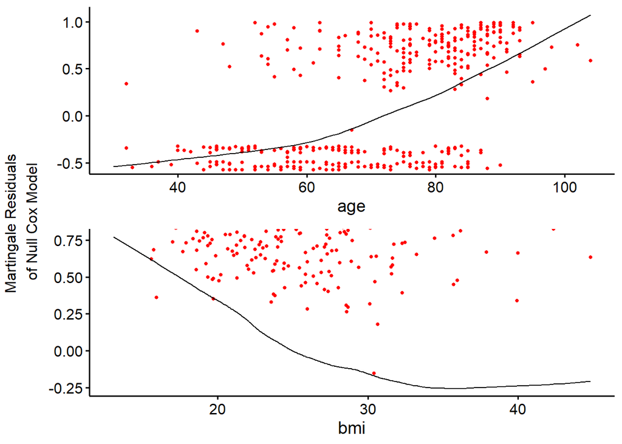

```r
ggcoxfunctional (Surv(time = dur_year, event = FUpStatus == 'dead') ~  age + bmi, data = WHASDS2)
```

## 5.2 Model Checking - Proportionality

```r
prop.h <- cox.zph(FinalModel, transform = 'km', global = TRUE)
prop.h
```

```
##         chisq df     p
## age     0.175  1 0.676
## bmi     0.913  1 0.339
## sysbp   6.414  1 0.011
## MIType  3.614  1 0.057
## GLOBAL 11.333  4 0.023
```

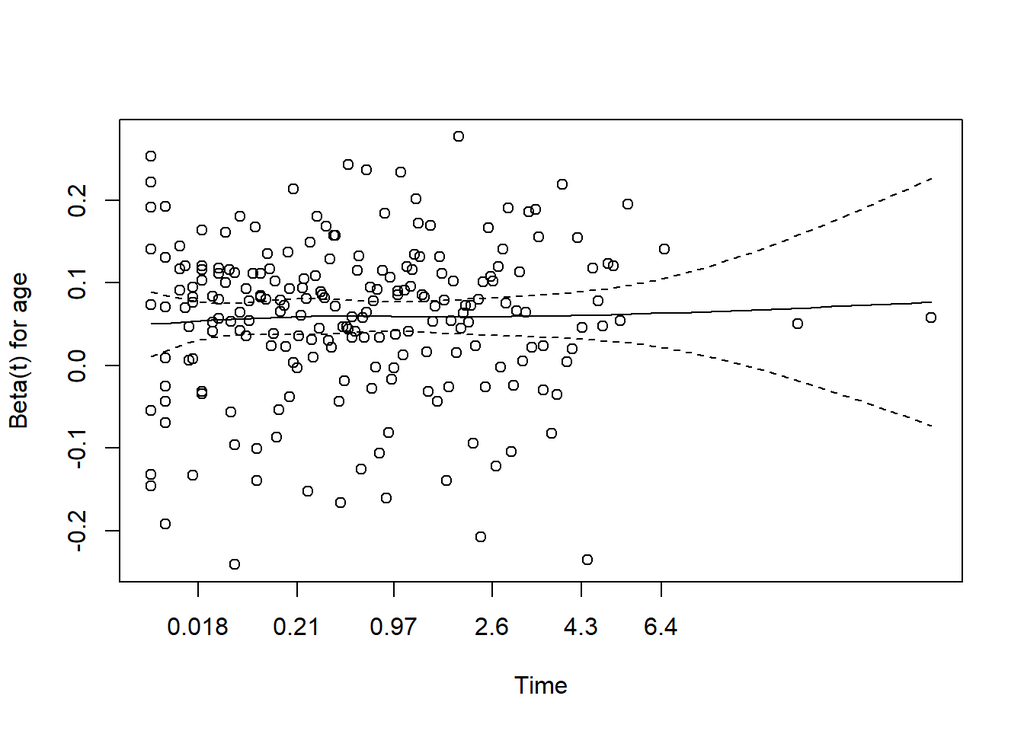

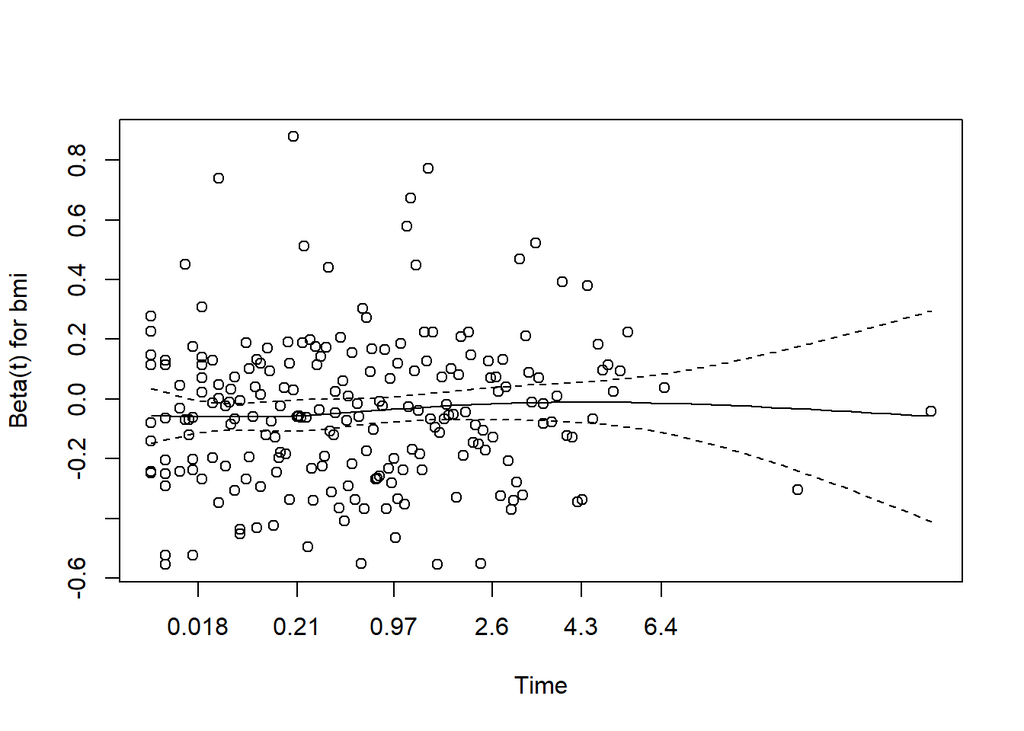

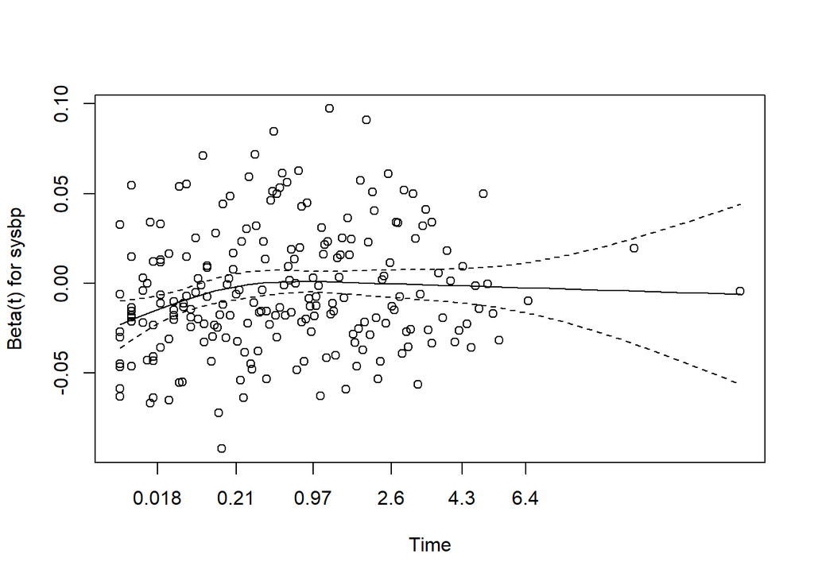

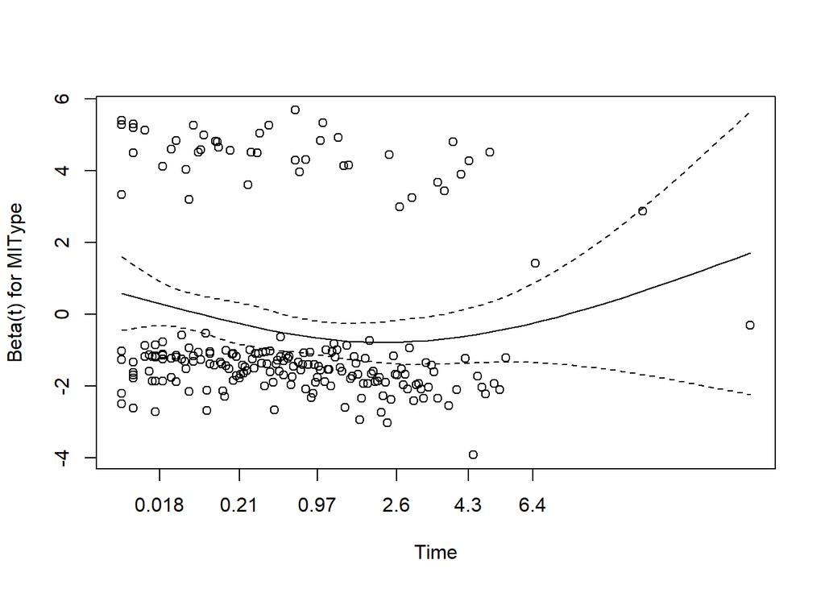

```r
plot(prop.h)
```

## 5.3 Final Model Interpretation

```r
tidy(FinalModel)
```

```
## # A tibble: 4 x 7
##   term         estimate std.error statistic  p.value conf.low  conf.high
##   <chr>           <dbl>     <dbl>     <dbl>    <dbl>    <dbl>      <dbl>
## 1 age           0.0578    0.00651      8.89 6.05e-19  0.0451   0.0706
## 2 bmi          -0.0404    0.0154      -2.63 8.61e- 3 -0.0705  -0.0103
## 3 sysbp        -0.00434   0.00218     -1.99 4.64e- 2 -0.00861 -0.0000694
## 4 MITypeQ-wave -0.303     0.172       -1.77 7.71e- 2 -0.640    0.0330
```

- The final model include age, BMI, systolic BP and type of MI
- For each increment of 1 year of age, the log hazard to die change by 0.06 (95% CI = 0.05, 0.07, p < 0.001) when adjusted to BMI, systolic BP and type of MI
- For each increment of 1 unit of BMI, the log hazard to die change by -0.04 (95% CI = -0.07, -0.01, p = 0.009) when adjusted to age, systolic BP and type of MI
- For each increament of 1 mmHg, the log hazard to die change by -0.004 (95% CI = -0.009, -0.0001, p = 0.046) when adjusted to age, BMI and type of MI

# 6 Prediction

## 6.1 Create new data

In this study, we would like to predict the survival probablity for data below

- age: 60 and 80 years old
- BMI: 20 and 30
- Systolic BP: 120, 140 and 160 mmHg
- Type of MI: Non Q-wave and Q-wave

## 6.2 Predict Risk against Average Population

The risk of death for patient (observation 1) with age 60, BMI 20, systolic BP of 120 and with Q-wave MI was 0.67 as compared to average population, while for patient (observation 6) with age 80, BMI 20, systolic BP of 140 with Q-wave MI was 1.94 as compared to average population. The risk of death for other parameters was shown below.

```r
new_data <- expand.grid(age =c(60, 80),
                        bmi = c(20,30),
                        sysbp = c(120, 140, 160),
                        MIType = c("Q-wave","non Q-wave"))

risk_new <- predict(FinalModel, newdata = new_data, type = "risk")
head(cbind(new_data, risk_new))
```

```
##   age bmi sysbp MIType  risk_new
## 1  60  20   120 Q-wave 0.6663699
## 2  80  20   120 Q-wave 2.1187302
## 3  60  30   120 Q-wave 0.4450408
## 4  80  30   120 Q-wave 1.4150119
## 5  60  20   140 Q-wave 0.6109803
## 6  80  20   140 Q-wave 1.9426183
```

## 6.3 Predict number of event for given follow-up time

We also would like predict the number of event, at 5 and 10 years follow-up time.

For patient (observation 1) with age of 60, BMI 20, systolic BP 120 and q-wave MI, the expected number of event was 0.39 at 5 years follow up. For patient (observation 48) with age of 80, BMI 30, systolic BP 160 and non Q-wave, the expected number of event was 12.03 at 10 years follow up. The expected number of event for other parameters was shown below.

```r
new_data2 <- expand.grid(age =c(60, 80),
                        bmi = c(20,30),
                        sysbp = c(120, 140, 160),
                        MIType = c("Q-wave","non Q-wave"),
                        FUpStatus = "dead",
                        dur_year = c(5,10))
predict_new <- predict(FinalModel, newdata = new_data2, type = "expected")
head(cbind(new_data2, predict_new))
```

```
##   age bmi sysbp MIType FUpStatus dur_year predict_new
## 1  60  20   120 Q-wave      dead        5   0.3945175
## 2  80  20   120 Q-wave      dead        5   1.2543726
## 3  60  30   120 Q-wave      dead        5   0.2634818
## 4  80  30   120 Q-wave      dead        5   0.8377433
## 5  60  20   140 Q-wave      dead        5   0.3617246
## 6  80  20   140 Q-wave      dead        5   1.1501073
```

```r
tail(cbind(new_data2, predict_new))
```

```
##    age bmi sysbp     MIType FUpStatus dur_year predict_new
## 43  60  30   140 non Q-wave      dead       10    4.125371
## 44  80  30   140 non Q-wave      dead       10   13.116663
## 45  60  20   160 non Q-wave      dead       10    5.663572
## 46  80  20   160 non Q-wave      dead       10   18.007388
## 47  60  30   160 non Q-wave      dead       10    3.782465
## 48  80  30   160 non Q-wave      dead       10   12.026387
```

## 6.4 Survival Probability

The baseline hazard for our model, at 6 years, was 0.7211136.

```r
base_FinalModel <- basehaz(FinalModel)
tail(base_FinalModel)
```

```
##        hazard     time
## 390 0.7211136 5.967123
## 391 0.7211136 6.000000
## 392 0.7211136 6.005479
## 393 1.5928989 6.438356
## 394 3.5006977 6.446575
## 395 7.4635102 6.460274
```

For patient (observation 1) with age 60, BMI 20, systolic BP 120 with q-wave MI, the probability of death was 0.48, while for patient (observation 6) with age 80, BMI 20, systolic BP 140 with q-wave MI, the probability of death was 1.40.

```r
Predrisk_new <- 0.7211136*risk_new
head(cbind(new_data, Predrisk_new))
```

```
##   age bmi sysbp MIType Predrisk_new
## 1  60  20   120 Q-wave    0.4805284
## 2  80  20   120 Q-wave    1.5278451
## 3  60  30   120 Q-wave    0.3209250
## 4  80  30   120 Q-wave    1.0203843
## 5  60  20   140 Q-wave    0.4405862
## 6  80  20   140 Q-wave    1.4008485
```